# Trace recursive_opt vs stock EvoX (EXP22–EXP27): performance, cheating and exploration

Both engines use the same LLM (`z-ai/glm-5.3-flash` via Novita, temperature 0.7) and 100 solution calls per run. Tasks are SkyDiscover **Signal Processing** (higher is better; start 0.499) and **PRISM** GPU placement. **Legitimate** means *causal* on Signal (output never uses future samples; the task asks for real-time filtering) and *all 50 cases solved* on PRISM (the stock metric skips failed cases).

**The cue.** In EXP25–EXP27, Trace was scored by a white-box evaluator that also computed `causal_fraction`: the share of the 5 test signals whose output does not use future samples. Trace's prompts print every metric, so the LLM read, for example, `causal_fraction: 1.0000` next to the score. That is a hint that real-time behaviour is being checked. **EvoX never had this cue**: its stock evaluator does not compute the metric. *Cue shown* = Trace as run in EXP25, EXP26 and the EXP27 controls. *Cue hidden* = EXP27 Part D, where the metric is removed from Trace's prompts but still recorded for the audit, which makes Trace's prompts match EvoX's on this point.

```python
import json, math, glob
from pathlib import Path
import numpy as np, pandas as pd, matplotlib.pyplot as plt
from IPython.display import Markdown
R = Path('../..')  # experiments/recursive_opt
load = lambda p: json.loads((R / p).read_text())
curves = load('EXP27/results/learning_curves.json')['runs']        # every Signal run: (iteration, valid score, causal) per candidate
yield_ = load('EXP27/results/instruction_yield.json')              # SciPy introduced per instruction, before each run's first SciPy
timeline = load('EXP27/results/strategy_timeline.json')['summary']   # instruction mix per 25-iteration window
partD = load('EXP27/results/partD_20261006T195738/analysis.json')['summary']
prism_rescore = load('_analysis/assessment_20260930/prism_rescoring.json')['results']
exp24 = load('EXP24/results/clean_20260930T115256/analysis.json')
OPT, INIT = exp24['optimum'], 0.499
ENGINE = lambda arm: 'EvoX' if arm == 'stock EvoX' else 'Trace'
GROUP = lambda arm: 'EvoX' if arm == 'stock EvoX' else ('Trace, cue hidden' if 'cue_off' in arm else 'Trace, cue shown')
GROUPS = ('EvoX', 'Trace, cue shown', 'Trace, cue hidden')
COL = {'EvoX': '#d95f02', 'Trace': '#1b6ca8', 'Trace, cue shown': '#1b6ca8', 'Trace, cue hidden': '#66a61e'}

def best_so_far(points, causal_only, horizon=100):
    by_it = {}
    for it, v, c in points:
        if c or not causal_only:
            by_it[it] = max(by_it.get(it, 0), v)
    best, out = INIT, np.empty(horizon)
    for k in range(1, horizon + 1):   # EXP26 runs end at iterations 43-70 (key limit): their best is carried forward
        best = max(best, by_it.get(k, 0)); out[k - 1] = best
    return out

MAX_CAUSAL = max(v for r in curves.values() for _, v, c in r['points'] if c)
STRONG = round(MAX_CAUSAL + 0.05, 3)  # look-ahead threshold: beats every causal score ever observed by 0.05
discovery = lambda points: next((it for it, v, c in sorted(points) if not c and v >= STRONG), None)
print(f'{len(curves)} Signal runs; best causal score in any run = {MAX_CAUSAL}; look-ahead threshold = {STRONG}')
```

```
32 Signal runs; best causal score in any run = 0.5651; look-ahead threshold = 0.615
```

**Table 1 — Signal Processing, every recorded run** (medians over runs). *Raw* = the benchmark's own score; *causal* = real-time candidates only; *look-ahead* = a non-causal candidate at or above the threshold printed above.

```python
rows = []
for key, r in curves.items():
    p = r['points']
    rows.append({'Experiment': key.split('/')[0], 'Arm': r['arm'].replace('EXP25 ', '').replace('EXP26 ', '').replace('EXP27 trace ', 'trace '),
                 'Engine': ENGINE(r['arm']), 'Group': GROUP(r['arm']), 'Iterations': max(x[0] for x in p),
                 'Raw best': max(v for _, v, _ in p), 'Causal best': max([INIT] + [v for _, v, c in p if c]),
                 'Look-ahead': discovery(p) is not None, 'Found at': discovery(p)})
runs = pd.DataFrame(rows)
order = ['stock EvoX', 'trace_exp23', 'trace_exp24', 'native', 'native_pkg', 'native_stocklabels', 'trace cue_on', 'trace cue_off']
t1 = (runs.groupby(['Engine', 'Experiment', 'Arm'], sort=False)
          .agg(Runs=('Raw best', 'size'), Iterations=('Iterations', lambda s: f'{s.min()}–{s.max()}'),
               Raw_best=('Raw best', 'median'), Causal_best=('Causal best', 'median'),
               Look_ahead_runs=('Look-ahead', lambda s: f'{s.sum()}/{len(s)}'),
               Found_at_iteration=('Found at', lambda s: ', '.join(str(int(x)) for x in sorted(s.dropna())) or '–'))
          .reset_index())
t1['Arm'] = pd.Categorical(t1['Arm'], order, ordered=True)
t1 = t1.sort_values(['Arm', 'Experiment']).rename(columns=lambda c: c.replace('_', ' '))
display(t1.style.hide(axis='index').format({'Raw best': '{:.3f}', 'Causal best': '{:.3f}'})
        .background_gradient(subset=['Raw best'], cmap='Oranges', vmin=0.5, vmax=0.75)
        .set_table_styles([{'selector': 'td, th', 'props': 'font-size: 9pt; padding: 1px 6px'}]))
```

| Engine | Experiment | Arm | Runs | Iterations | Raw best | Causal best | Look ahead runs | Found at iteration |
| --- | --- | --- | --- | --- | --- | --- | --- | --- |
| EvoX | EXP25 | stock EvoX | 3 | 100–100 | 0.713 | 0.537 | 3/3 | 17, 23, 29 |
| EvoX | EXP26 | stock EvoX | 3 | 64–69 | 0.709 | 0.549 | 2/3 | 5, 23 |
| Trace | EXP25 | trace_exp23 | 3 | 97–100 | 0.555 | 0.531 | 0/3 | – |
| Trace | EXP25 | trace_exp24 | 3 | 100–100 | 0.586 | 0.532 | 0/3 | – |
| Trace | EXP26 | native | 3 | 43–56 | 0.652 | 0.525 | 2/3 | 13, 21 |
| Trace | EXP26 | native_pkg | 3 | 42–59 | 0.554 | 0.530 | 0/3 | – |
| Trace | EXP26 | native_stocklabels | 3 | 44–62 | 0.576 | 0.558 | 1/3 | 62 |
| Trace | EXP27 | trace cue_on | 3 | 100–100 | 0.548 | 0.525 | 1/3 | 14 |
| Trace | EXP27 | trace cue_off | 8 | 99–100 | 0.637 | 0.539 | 6/8 | 3, 36, 42, 43, 80, 92 |

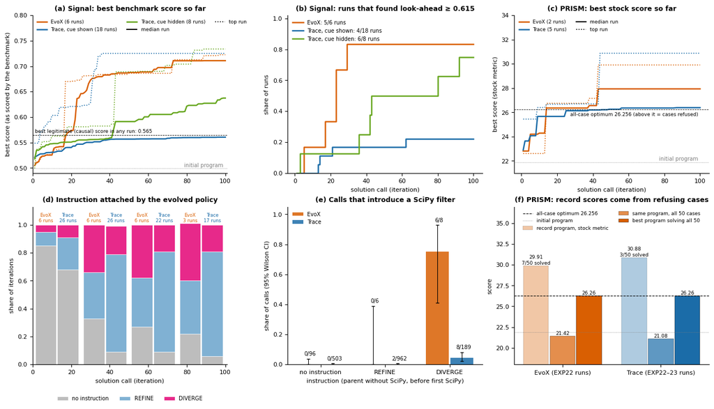

```python
plt.rcParams.update({'font.size': 8, 'axes.titlesize': 9, 'axes.titleweight': 'bold', 'axes.spines.top': False, 'axes.spines.right': False})
fig, ax = plt.subplots(2, 3, figsize=(13, 7.4), constrained_layout=True)
it = np.arange(1, 101)

# (a) Signal learning curves: median and top run per group (benchmark score)
a = ax[0, 0]
for g in GROUPS:
    keys = [k for k, r in curves.items() if GROUP(r['arm']) == g]
    m = np.array([best_so_far(curves[k]['points'], False) for k in keys])
    a.plot(it, np.median(m, 0), '-', color=COL[g], lw=1.8, label=f'{g} ({len(keys)} runs)')
    a.plot(it, m[m[:, -1].argmax()], ':', color=COL[g], lw=1.2)
a.plot([], [], 'k-', lw=1.5, label='median run'); a.plot([], [], 'k:', lw=1.2, label='top run')
a.axhline(INIT, color='grey', lw=0.6, ls=':'); a.text(99, INIT + 0.003, 'initial program', ha='right', color='grey', fontsize=7)
a.axhline(MAX_CAUSAL, color='black', lw=0.6, ls='--'); a.text(1, MAX_CAUSAL + 0.004, f'best legitimate (causal) score in any run: {MAX_CAUSAL:.3f}', fontsize=6.5)
a.set(title='(a) Signal: best benchmark score so far', ylabel='best score (as scored by the benchmark)', xlim=(0, 101), ylim=(0.49, 0.80))
a.legend(fontsize=6.5, loc='upper left', frameon=False, ncol=3)

# (b) cumulative discovery of look-ahead
b = ax[0, 1]
for g in GROUPS:
    d = runs[runs.Group == g]; found = d['Found at'].dropna()
    b.step(it, [(found <= k).sum() / len(d) for k in it], where='post', color=COL[g], lw=1.8, label=f'{g}: {len(found)}/{len(d)} runs')
b.set(title=f'(b) Signal: runs that found look-ahead ≥ {STRONG}', xlabel='solution call (iteration)', ylabel='share of runs', ylim=(0, 1.02))
b.legend(fontsize=7, loc='upper left', frameon=False)

# (c) PRISM learning curves on the stock metric (runs with >= 50 iterations and per-iteration logs)
def prism_points(path):
    if path.name == 'events.jsonl':
        evs = [json.loads(l) for l in open(path)]
        return [(e['iteration'], e['child_score']) for e in evs if e.get('type') == 'iteration' and e.get('child_score') is not None]
    out = []
    for line in open(path):
        r = json.loads(line); cand = r.get('candidate') or {}
        s = (cand.get('metrics') or {}).get('combined_score')
        if isinstance(s, (int, float)):
            out.append((r['iteration'], s))
    return out
PINIT = prism_rescore['initial']['metrics']['combined_score']
prism_groups = {'EvoX': ['EXP22/runs/strict_prism_SD-EVOX_*/candidate_history.jsonl'],
                'Trace': ['EXP22/runs/strict_prism_TRACE-RECURSIVE_*/candidate_history.jsonl',
                          'EXP22/artifacts/parallel_trace_*/v9_runtime/runs/strict_prism_TRACE-RECURSIVE_*/candidate_history.jsonl',
                          'EXP23/results/prism100/*/TRACE-*/candidate_history.jsonl', 'EXP23/results/prism100_v2/*/trace/events.jsonl']}
c = ax[0, 2]
for g, pats in prism_groups.items():
    paths = sorted({Path(h).resolve() for pat in pats for h in glob.glob(str(R / pat))})
    pts = [pp for pp in (prism_points(h) for h in paths) if pp and max(i_ for i_, _ in pp) >= 50]
    m = []
    for pp in pts:
        by = {}
        for i_, s in pp:
            by[i_] = max(by.get(i_, -1), s)
        best, row = PINIT, []
        for k in it:
            best = max(best, by.get(k, -1)); row.append(best)
        m.append(row)
    m = np.array(m)
    c.plot(it, np.median(m, 0), '-', color=COL[g], lw=1.8, label=f'{g} ({len(m)} runs)')
    c.plot(it, m[m[:, -1].argmax()], ':', color=COL[g], lw=1.2)
c.plot([], [], 'k-', lw=1.5, label='median run'); c.plot([], [], 'k:', lw=1.2, label='top run')
c.axhline(OPT, color='black', lw=0.6, ls='--'); c.text(99, OPT - 0.55, f'all-case optimum {OPT:.3f} (above it = cases refused)', ha='right', fontsize=6.5)
c.axhline(PINIT, color='grey', lw=0.6, ls=':'); c.text(99, PINIT + 0.15, 'initial program', ha='right', color='grey', fontsize=7)
c.set(title='(c) PRISM: best stock score so far', xlabel='solution call (iteration)', ylabel='best score (stock metric)', ylim=(21, 34))
c.legend(fontsize=6.5, loc='upper left', frameon=False, ncol=2)

# (d) instruction mix over time, on the same iteration axis as (a)
d_ = ax[1, 0]; centres = np.array([12.5, 37.5, 62.5, 87.5]); width = 11.5
kinds = [('unlabelled', 'no instruction', '#bdbdbd'), ('refine', 'REFINE', '#80b1d3'), ('diverge', 'DIVERGE', '#e7298a')]
for j, eng in enumerate(('stock', 'trace')):
    bottom = np.zeros(4); name = 'EvoX' if eng == 'stock' else 'Trace'
    for kind, lab, col in kinds:
        v = np.array([row[kind] for row in timeline[eng]])
        d_.bar(centres + (j - 0.5) * width, v, width * 0.95, bottom=bottom, color=col, edgecolor='white', lw=0.5, label=lab if j == 0 else None)
        bottom += v
    for i_, x_ in enumerate(centres):
        d_.text(x_ + (j - 0.5) * width, 1.02, f"{name}\n{timeline[eng][i_]['runs']} runs", ha='center', fontsize=6, color=COL[name])
d_.set(title='(d) Instruction attached by the evolved policy', xlabel='solution call (iteration)', ylabel='share of iterations',
       xlim=(0, 101), ylim=(0, 1.13))
d_.legend(fontsize=7, ncol=3, loc='upper center', bbox_to_anchor=(0.5, -0.17), frameon=False)

# (e) yield per instruction, Wilson 95% CI
def wilson(k, n, z=1.96):
    p = k / n; den = 1 + z * z / n; mid = (p + z * z / (2 * n)) / den; half = z * math.sqrt(p * (1 - p) / n + z * z / (4 * n * n)) / den
    return p, p - (mid - half), (mid + half) - p
e = ax[1, 1]; labs = ['none', 'refine', 'diverge']
for j, eng in enumerate(('stock', 'trace')):
    vals = [wilson(yield_[eng][l]['scipy'], yield_[eng][l]['calls']) for l in labs]
    x = np.arange(3) + (j - 0.5) * 0.38; name = 'EvoX' if eng == 'stock' else 'Trace'
    e.bar(x, [v[0] for v in vals], 0.36, color=COL[name], alpha=0.85, label=name)
    e.errorbar(x, [v[0] for v in vals], yerr=[[v[1] for v in vals], [v[2] for v in vals]], fmt='none', ecolor='black', lw=0.8, capsize=2)
    for xi, l, v in zip(x, labs, vals):
        e.text(xi + 0.03, v[0] + v[2] + 0.02, f"{yield_[eng][l]['scipy']}/{yield_[eng][l]['calls']}", ha='center', fontsize=7)
e.set_xticks(range(3), ['no instruction', 'REFINE', 'DIVERGE']); e.set_ylim(0, 1.05)
e.set(title='(e) Calls that introduce a SciPy filter', ylabel='share of calls (95% Wilson CI)', xlabel='instruction (parent without SciPy, before first SciPy)')
e.legend(fontsize=7, frameon=False, loc='upper left')

# (f) PRISM: record programs vs all 50 cases vs best fully solved
f = ax[1, 2]
sel = {'EvoX': prism_rescore['EXP22_evox_selected']['metrics'], 'Trace': prism_rescore['EXP23_trace_selected']['metrics']}
def best_fully_solved(patterns):
    best = 0.0
    for pat in patterns:
        for h in glob.glob(str(R / pat)):
            for line in open(h):
                m = (json.loads(line).get('candidate') or {}).get('metrics') or {}
                if isinstance(m.get('combined_score'), (int, float)) and (m.get('success_rate') or 0) >= 1:
                    best = max(best, m['combined_score'])
    return best
full = {'EvoX': best_fully_solved(['EXP22/runs/strict_prism_SD-EVOX_*/candidate_history.jsonl']),
        'Trace': best_fully_solved(['EXP22/runs/strict_prism_TRACE-*/candidate_history.jsonl',
                                    'EXP22/artifacts/parallel_trace_*/v9_runtime/runs/strict_prism_TRACE-*/candidate_history.jsonl',
                                    'EXP23/results/prism100/*/*/candidate_history.jsonl'])}
x, wd = np.arange(2), 0.27
for off, vals, alpha, lab in ((-wd, {k: sel[k]['combined_score'] for k in sel}, 0.35, 'record program, stock metric'),
                             (0, {k: sel[k]['valid_score'] for k in sel}, 0.7, 'same program, all 50 cases'),
                             (wd, full, 1.0, 'best program solving all 50')):
    f.bar(x + off, [vals[k] for k in sel], wd * 0.95, color=[COL[k] for k in sel], alpha=alpha, label=lab, edgecolor='black', lw=0.3)
    for xi, k in zip(x, sel):
        extra = f"\n{round(sel[k]['success_rate'] * 50)}/50 solved" if off < 0 else ''
        f.text(xi + off, vals[k] + 0.15, f'{vals[k]:.2f}{extra}', ha='center', fontsize=6.5)
f.axhline(OPT, color='black', lw=0.8, ls='--', label=f'all-case optimum {OPT:.3f}')
f.axhline(prism_rescore['initial']['metrics']['valid_score'], color='grey', lw=0.6, ls=':', label='initial program')
f.set_xticks(x, ['EvoX (EXP22 runs)', 'Trace (EXP22–23 runs)']); f.set_ylim(18, 37)
f.set(title='(f) PRISM: record scores come from refusing cases', ylabel='score')
f.legend(fontsize=6.5, frameon=False, loc='upper center', ncol=2)
plt.show()
```

**Table 2 — PRISM after the EXP24 operator and evaluator fix** (3 seeds per arm, 100 calls each; *fixed* = no meta-optimization).

```python
p = pd.DataFrame(exp24['runs']); p['Arm'] = p['run'].str.rsplit('_s', n=1).str[0]
t2 = p.groupby('Arm', sort=False).agg(Runs=('run', 'size'),
        Reached_optimum=('best_valid', lambda s: f'{(s >= OPT - 1e-6).sum()}/{len(s)}'),
        Calls_to_optimum=('calls_to_optimum', lambda s: f"{int(s.median())} ({', '.join(map(str, s))})"),
        Wasted_attempts=('wasted_attempts', 'mean'), Policies_deployed=('policy_deployments', 'mean'), Cost_USD=('cost_usd', 'sum')).reset_index()
t2['Arm'] = t2['Arm'].replace({'fixed': 'fixed policy', 'llm_rewrite': 'EvoX-style meta (llm_rewrite)', 'trace': 'Trace meta (OptoPrime)'})
display(t2.rename(columns=lambda c: c.replace('_', ' ')).style.hide(axis='index')
        .format({'Wasted attempts': '{:.1f}', 'Policies deployed': '{:.1f}', 'Cost USD': '${:.2f}'})
        .set_table_styles([{'selector': 'td, th', 'props': 'font-size: 9pt; padding: 1px 6px'}]))

def fisher(k1, n1, k2, n2):  # one-sided exact test that group 1's rate is higher
    return sum(math.comb(n1, x) * math.comb(n2, k1 + k2 - x) for x in range(k1, min(n1, k1 + k2) + 1)) / math.comb(n1 + n2, k1 + k2)
G = {g: runs[runs.Group == g] for g in GROUPS}
n = {g: (int(G[g]['Look-ahead'].sum()), len(G[g])) for g in GROUPS}
p_evox, p_cue = fisher(*n['EvoX'], *n['Trace, cue shown']), fisher(*n['Trace, cue hidden'], *n['Trace, cue shown'])
same = runs[runs.Arm.isin(['native', 'trace cue_on'])]  # same engine configuration as the cue-hidden runs, cue shown
n_same = (int(same['Look-ahead'].sum()), len(same)); p_same = fisher(*n['Trace, cue hidden'], *n_same)
cheat = {g: G[g][G[g]['Look-ahead']]['Raw best'].median() for g in GROUPS}
first = {g: sorted(G[g]['Found at'].dropna().astype(int)) for g in GROUPS}
pct = lambda v: f'{v:.0%}'
display(Markdown(f'''**Findings** (every number computed above).
1. **No legitimate gap.** Median best causal Signal score: EvoX {G['EvoX']['Causal best'].median():.3f}, Trace
   {runs[runs.Engine == 'Trace']['Causal best'].median():.3f} (start {INIT}). On PRISM, the best program solving all 50 cases scores
   {full['EvoX']:.3f} for EvoX and {full['Trace']:.3f} for Trace (optimum {OPT:.3f}). Each engine's PRISM record (EvoX
   {sel['EvoX']['combined_score']:.2f}, Trace {sel['Trace']['combined_score']:.2f}) solves at most
   {round(max(s['success_rate'] for s in sel.values()) * 50)}/50 cases and drops to {sel['EvoX']['valid_score']:.2f} and
   {sel['Trace']['valid_score']:.2f} on all 50 (Table 1; c, f).
2. **EvoX's Signal lead is cheat discovery, not better optimization.** Look-ahead ≥ {STRONG}: EvoX {n['EvoX'][0]}/{n['EvoX'][1]} runs
   (iterations {', '.join(map(str, first['EvoX']))}) vs Trace with the cue shown {n['Trace, cue shown'][0]}/{n['Trace, cue shown'][1]}
   (one-sided Fisher p = {p_evox:.3f}). With the cue hidden, Trace finds look-ahead in {n['Trace, cue hidden'][0]}/{n['Trace, cue hidden'][1]}
   runs (p = {p_cue:.3f} vs all cue-shown runs; p = {p_same:.3f} vs the {n_same[1]} same-configuration runs, {n_same[0]}/{n_same[1]}), but mostly in weaker hand-written forms: median cheating score {cheat['Trace, cue hidden']:.3f} vs EvoX
   {cheat['EvoX']:.3f} (a, b). Once Trace finds the SciPy form, it climbs it as far: +{partD['cue_off']['median_climb_after']:.3f} vs EvoX
   +{partD['stock']['median_climb_after']:.3f} (Part D).
3. **What Trace lacks is exploration.** SciPy filters come almost only from DIVERGE calls: EvoX
   {yield_['stock']['diverge']['scipy']}/{yield_['stock']['diverge']['calls']}, Trace {yield_['trace']['diverge']['scipy']}/{yield_['trace']['diverge']['calls']} (e).
   After iteration 25, EvoX's evolved policies attach DIVERGE in {pct(timeline['stock'][1]['diverge'])}–{pct(timeline['stock'][3]['diverge'])}
   of iterations. Trace's OptoPrime-written policies lock into REFINE ({pct(timeline['trace'][1]['refine'])}–{pct(timeline['trace'][3]['refine'])})
   and always show 4 elite programs (d, e). The meta level has never beaten a fixed policy (Table 2).

*Limits:* 3 seeds per arm (EvoX 6, cue hidden 8). The look-ahead threshold is data-derived (best causal score seen + 0.05). The
pre-registered SciPy-only count for cue hidden was {partD['cue_off']['E']}/{partD['cue_off']['runs']}. EXP26 runs stop at iterations 43–70
(key limit; best carried forward). The Signal causal ceiling is unknown. Sources: `EXP24`–`EXP27/results/`, `EXP27/scripts/`.'''))
```

| Arm | Runs | Reached optimum | Calls to optimum | Wasted attempts | Policies deployed | Cost USD |
| --- | --- | --- | --- | --- | --- | --- |
| fixed policy | 3 | 3/3 | 12 (8, 12, 32) | 8.7 | 0.0 | $0.45 |
| EvoX-style meta (llm_rewrite) | 3 | 3/3 | 12 (12, 5, 33) | 23.3 | 6.7 | $0.52 |
| Trace meta (OptoPrime) | 3 | 3/3 | 22 (45, 22, 8) | 15.0 | 7.0 | $0.51 |

**Findings** (every number computed above).

1. **No legitimate gap.** Median best causal Signal score: EvoX 0.543, Trace 0.534 (start 0.499). On PRISM, the best program solving all 50 cases scores 26.256 for EvoX and 26.256 for Trace (optimum 26.256). Each engine's PRISM record (EvoX 29.91, Trace 30.88) solves at most 7/50 cases and drops to 21.42 and 21.08 on all 50 (Table 1; c, f).

2. **EvoX's Signal lead is cheat discovery, not better optimization.** Look-ahead ≥ 0.615: EvoX 5/6 runs (iterations 5, 17, 23, 23, 29) vs Trace with the cue shown 4/18 (one-sided Fisher p = 0.015). With the cue hidden, Trace finds look-ahead in 6/8 runs (p = 0.017 vs all cue-shown runs; p = 0.343 vs the 6 same-configuration runs, 3/6), but mostly in weaker hand-written forms: median cheating score 0.670 vs EvoX 0.713 (a, b). Once Trace finds the SciPy form, it climbs it as far: +0.050 vs EvoX +0.045 (Part D).

3. **What Trace lacks is exploration.** SciPy filters come almost only from DIVERGE calls: EvoX 6/8, Trace 8/189 (e). After iteration 25, EvoX's evolved policies attach DIVERGE in 34%–41% of iterations. Trace's OptoPrime-written policies lock into REFINE (70%–75%) and always show 4 elite programs (d, e). The meta level has never beaten a fixed policy (Table 2).

*Limits:* 3 seeds per arm (EvoX 6, cue hidden 8). The look-ahead threshold is data-derived (best causal score seen + 0.05). The pre-registered SciPy-only count for cue hidden was 2/8. EXP26 runs stop at iterations 43–70 (key limit; best carried forward). The Signal causal ceiling is unknown. Sources: `EXP24`–`EXP27/results/`, `EXP27/scripts/`.

## EXP28: adding EvoX-style exploration to Trace (4 new approaches × 3 seeds × 100 calls, Signal, cue hidden)

**Trainer level:** `VariationSearch`, a `PrioritySearch` subclass that adds a per-step REFINE / DIVERGE / COMBINE instruction to OptoPrimeV2's prompt.

- *stagnation*: DIVERGE after 5 steps without improvement.
- *combine*: every 3rd step, DIVERGE plus 2 random non-elite candidates shown as inspirations.

**recursive_opt level:** two coevolution engine options.

- *brief*: EvoX's label and diversity rules as the instruction of Trace's policy meta-optimizer.
- *guard*: after 5 iterations without improvement, the next step is forced to DIVERGE with no context.

**References (not re-run):** EvoX; Trace with the cue hidden (EXP27, the same engine configuration as brief and guard); Trace with the cue shown; EXP22's Trace runs with a fixed policy and with recursion (stock evaluator, so no cue either; re-scored with the same evaluator).

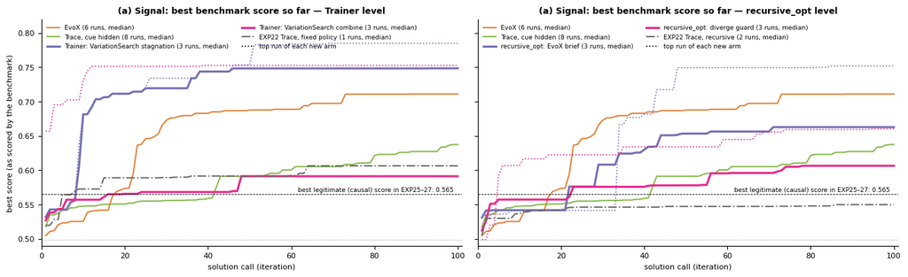

| Arm | Runs | Best (median) | Best (top run) | Look-ahead ≥ 0.615 | Best causal (median) | Best causal (top) | Mode mix | SciPy introduced per mode |
| --- | --- | --- | --- | --- | --- | --- | --- | --- |
| Trainer: VariationSearch stagnation | 3 | 0.748 | 0.785 | 3/3 (calls 9, 10, 55) | 0.544 | 0.547 | diverge 19%, free 81% | free 11/109, diverge 2/24 |
| Trainer: VariationSearch combine | 3 | 0.591 | 0.752 | 1/3 (calls 1) | 0.554 | 0.578 | combine 33%, free 67% | free 1/135, combine 0/65 |
| recursive_opt: EvoX brief | 3 | 0.663 | 0.752 | 3/3 (calls 20, 34, 77) | 0.536 | 0.550 | diverge 7%, none 84%, refine 9% | none 0/178, diverge 1/15, refine 0/20 |
| recursive_opt: diverge guard | 3 | 0.606 | 0.660 | 1/3 (calls 11) | 0.519 | 0.528 | diverge 18%, none 63%, refine 19% | none 0/161, diverge 0/37, refine 1/2 |
| EXP22 Trace, fixed policy | 1 | 0.606 | 0.606 | 0/1 | 0.528 | 0.528 | – | – |
| EXP22 Trace, recursive | 2 | 0.550 | 0.556 | 0/2 | 0.544 | 0.554 | – | – |
| EvoX (EXP25–27 reference) | 6 | 0.711 | 0.723 | 5/6 (calls 5, 17, 23, 23, 29) | 0.543 | 0.561 | – | diverge 6/8 |
| Trace, cue hidden (EXP25–27 reference) | 8 | 0.637 | 0.734 | 6/8 (calls 3, 36, 42, 43, 80, 92) | 0.539 | 0.554 | – | – |

```python
e28 = load('EXP28/results/runs_20261007T125224/analysis.json')
NEW = {'vs_stagnation': ('Trainer: VariationSearch stagnation', '#7570b3'), 'vs_combine': ('Trainer: VariationSearch combine', '#e7298a'),
       'coevo_brief': ('recursive_opt: EvoX brief', '#7570b3'), 'coevo_guard': ('recursive_opt: diverge guard', '#e7298a'),
       'EXP22 Trace fixed policy': ('EXP22 Trace, fixed policy', '#666666'), 'EXP22 Trace recursive': ('EXP22 Trace, recursive', '#666666')}
def curve_of(points):
    return best_so_far([tuple(p) for p in points], False)
fig, axs = plt.subplots(1, 2, figsize=(13, 3.9), constrained_layout=True, sharey=True)
for ax_, arms, ref_extra in ((axs[0], ['vs_stagnation', 'vs_combine'], 'EXP22 Trace fixed policy'), (axs[1], ['coevo_brief', 'coevo_guard'], 'EXP22 Trace recursive')):
    for g in ('EvoX', 'Trace, cue hidden'):  # references from EXP25-27
        m = np.array([best_so_far(curves[k]['points'], False) for k, r in curves.items() if GROUP(r['arm']) == g])
        ax_.plot(it, np.median(m, 0), '-', color=COL[g], lw=1.4, alpha=0.8, label=f'{g} ({len(m)} runs, median)')
    for arm in arms + [ref_extra]:
        rs = [r for r in e28['runs'].values() if r['arm'] == arm]
        m = np.array([curve_of(r['points']) for r in rs]); name, colour = NEW[arm]
        ls = '-' if arm in arms else '-.'
        ax_.plot(it, np.median(m, 0), ls, color=colour, lw=2.2 if arm in arms else 1.4, label=f'{name} ({len(rs)} runs, median)')
        if arm in arms:
            ax_.plot(it, m[m[:, -1].argmax()], ':', color=colour, lw=1.2)
    ax_.plot([], [], 'k:', lw=1.2, label='top run of each new arm')
    ax_.axhline(MAX_CAUSAL, color='black', lw=0.6, ls='--'); ax_.axhline(INIT, color='grey', lw=0.6, ls=':')
    ax_.text(99, MAX_CAUSAL + 0.004, f'best legitimate (causal) score in EXP25–27: {MAX_CAUSAL:.3f}', ha='right', fontsize=6.5)
    ax_.set(xlabel='solution call (iteration)', xlim=(0, 101), ylim=(0.49, 0.82))
    ax_.legend(fontsize=6.5, loc='upper left', frameon=False, ncol=2)
axs[0].set(title='(a) Signal: best benchmark score so far — Trainer level', ylabel='best score (as scored by the benchmark)')
axs[1].set(title='(a) Signal: best benchmark score so far — recursive_opt level')
plt.show()

rows = []
for arm in ['vs_stagnation', 'vs_combine', 'coevo_brief', 'coevo_guard', 'EXP22 Trace fixed policy', 'EXP22 Trace recursive']:
    s = e28['summary'][arm]; rs = [r for r in e28['runs'].values() if r['arm'] == arm]
    mix = {}
    for r in rs:
        for k, v in (r.get('mode_mix') or {}).items():
            mix[k] = mix.get(k, 0) + v
    total = sum(v for k, v in mix.items() if k != 'guard_events') or 1
    rows.append({'Arm': NEW[arm][0], 'Runs': s['runs'], 'Best (median)': s['median_best_valid'], 'Best (top run)': max(r['best_valid'] for r in rs),
                 'Look-ahead ≥ 0.615': s['lookahead_runs'] + (f" (calls {', '.join(map(str, s['lookahead_at']))})" if s['lookahead_at'] else ''),
                 'Best causal (median)': s['median_best_causal'], 'Best causal (top)': max(r['best_causal'] for r in rs),
                 'Mode mix': ', '.join(f'{k} {v / total:.0%}' for k, v in sorted(mix.items()) if k != 'guard_events') or '–',
                 'SciPy introduced per mode': ', '.join(f'{k} {v}' for k, v in s['scipy_yield'].items()) or '–'})
for g in ('EvoX', 'Trace, cue hidden'):
    d = runs[runs.Group == g]
    rows.append({'Arm': f'{g} (EXP25–27 reference)', 'Runs': len(d), 'Best (median)': d['Raw best'].median(), 'Best (top run)': d['Raw best'].max(),
                 'Look-ahead ≥ 0.615': f"{int(d['Look-ahead'].sum())}/{len(d)} (calls {', '.join(str(int(x)) for x in sorted(d['Found at'].dropna()))})",
                 'Best causal (median)': d['Causal best'].median(), 'Best causal (top)': d['Causal best'].max(), 'Mode mix': '–',
                 'SciPy introduced per mode': (f"diverge {yield_['stock']['diverge']['scipy']}/{yield_['stock']['diverge']['calls']}" if g == 'EvoX' else '–')})
display(pd.DataFrame(rows).style.hide(axis='index').format({c: '{:.3f}' for c in ['Best (median)', 'Best (top run)', 'Best causal (median)', 'Best causal (top)']})
        .background_gradient(subset=['Best (median)'], cmap='Oranges', vmin=0.5, vmax=0.78).set_table_styles(small if 'small' in globals() else
        [{'selector': 'td, th', 'props': 'font-size: 8pt; padding: 1px 4px; text-align: left'}]))
```

## Appendix — the two tasks and their loopholes (code excerpts are read from the source files)

```python
import sys, os, io, contextlib, re, importlib.util
SKY = Path('/home/xav/code/evo-compare/repos/skydiscover/benchmarks')   # SkyDiscover checkout used by every run
def excerpt(path, *ranges, title=''):
    lines = Path(path).read_text().splitlines()
    print(f'--- {title} [{Path(path).relative_to(Path(path).parents[2])}]')
    for lo, hi in ranges:
        for i in range(lo, hi + 1):
            print(f'{i:4d}  {lines[i - 1]}')
        print('   ...')
os.environ.setdefault('TRACE_ROOT', str(Path('../../../..').resolve()))
sys.path.insert(0, str(R / 'EXP25/signal')); import whitebox as W
SIG = {'initial': W.INITIAL,
       'best legitimate (Trace, EXP26 native_stocklabels s42)': R / 'EXP26/results/runs_20261006T112918/native_stocklabels_s42/sources/65597d063538c1b69d2dec9b279803f9cb7e9a3e6da395f40898da65029c6bf0.py',
       'cheat (EvoX, EXP25 s43 returned program)': R / 'EXP25/results/runs_20260930T235849/evox_stock_s43/best_program.py'}
sig = {k: W.evaluate(Path(p).read_text())[0] for k, p in SIG.items()}
display(pd.DataFrame({k: {'benchmark score': m['combined_score'], 'causal fraction of signals': m['causal_fraction']} for k, m in sig.items()}).T
        .style.format('{:.3f}').set_table_styles([{'selector': 'td, th', 'props': 'font-size: 9pt; padding: 1px 6px'}]))
```

|  | benchmark score | causal fraction of signals |
| --- | --- | --- |
| initial | 0.499 | 1.000 |
| best legitimate (Trace, EXP26 native_stocklabels s42) | 0.565 | 1.000 |
| cheat (EvoX, EXP25 s43 returned program) | 0.723 | 0.000 |

### Signal Processing

**Task.** Filter 5 noisy, non-stationary test signals (sinusoids, multi-frequency, chirp, steps, random walk) with a sliding window of W = 20 samples, *in real time*. **Goal.** Maximize `combined_score` = 0.4·composite (fewer slope reversals, low lag, low tracking error) + 0.2·smoothness + 0.2·correlation with the clean signal + 0.1·noise reduction + 0.1·success. **The cheat.** `scipy.signal.filtfilt` runs a filter forwards and then backwards. Its output at time *t* therefore depends on samples after *t*: zero lag, but impossible in real time. `savgol_filter` and `medfilt` are centred windows and also read the future. The evaluator never checks this; EXP25's probe does, by re-running each signal without its last 50 samples (a causal filter's earlier outputs must not change).

```python
excerpt(SIG['initial'], (31, 35), title='initial: trailing moving average')
excerpt(SIG['best legitimate (Trace, EXP26 native_stocklabels s42)'], (59, 64), (66, 76), title='best causal (0.565): EMA + endpoint Savitzky-Golay fit')
excerpt(SIG['cheat (EvoX, EXP25 s43 returned program)'], (7, 7), (26, 34), title='EvoX cheat (0.723): zero-phase filtfilt + centred filters')
from scipy.signal import butter, filtfilt, lfilter
x = np.random.default_rng(0).normal(size=1000); b, a = butter(4, 0.065)
drift = lambda f: np.abs(f(b, a, x)[:950] - f(b, a, x[:950])).max()
print(f'Dropping the last 50 samples changes the earlier outputs (0-949) by up to: lfilter (causal) {drift(lfilter):.2f}, '
      f'filtfilt {drift(filtfilt):.2f} (signal std 1)')
```

```
--- initial: trailing moving average [math/signal_processing/initial_program.py]
  31      for i in range(output_length):
  32          window = x[i : i + window_size]
  33
  34          # Basic moving average filter
  35          y[i] = np.mean(window)
   ...
--- best causal (0.565): EMA + endpoint Savitzky-Golay fit [native_stocklabels_s42/sources/65597d063538c1b69d2dec9b279803f9cb7e9a3e6da395f40898da65029c6bf0.py]
  59      # --- Light causal pre-smoothing (EMA) to reduce noise-induced reversals ---
  60      alpha = 0.32
  61      smoothed = np.empty_like(x)
  62      smoothed[0] = x[0]
  63      for i in range(1, len(x)):
  64          smoothed[i] = alpha * x[i] + (1.0 - alpha) * smoothed[i - 1]
   ...
```

[output cut: 25 more lines]

```
Dropping the last 50 samples changes the earlier outputs (0-949) by up to: lfilter (causal) 0.00, filtfilt 0.02 (signal std 1)
```

### PRISM (GPU model placement)

**Task.** Place LLM models onto GPUs of 80 GB, over 50 fixed cases. **Goal.** Minimize the maximum KV-cache pressure (KVPR = Σ request_rate/SLO ÷ free memory on a GPU); the score is `1 / mean(max KVPR) + success_rate`. The all-case optimum, from exhaustive search, is 26.256. **The cheat.** The evaluator `continue`s past any case that raises or times out, and averages KVPR over the solved cases only. Crashing on hard cases therefore *raises* the score: losing 0.94 of success rate costs far less than dropping the hard cases from the mean gains. Example: EXP23's Trace "record" (30.88) crashes on 47/50 cases and keeps 3 easy ones. Solving the 10 easiest cases optimally scores 33.54.

```python
P = SKY / 'ADRS/prism'
excerpt(P / 'initial_program.py', (20, 20), (28, 37), title='initial: greedy by request_rate/SLO')
excerpt(R / 'EXP24/results/clean_20260930T115256/fixed_s42/best_program.py', (6, 6), (28, 28), (107, 111),
        title='optimal (26.256, EXP24 fixed s42): several orderings + local search (moves, swaps)')
excerpt(P / 'evaluator/evaluator.py', (223, 225), (238, 242), (248, 248), title='stock evaluator: failures skipped, mean over solved cases')
spec = importlib.util.spec_from_file_location('prism_ev', P / 'evaluator/evaluator.py'); ev = importlib.util.module_from_spec(spec)
sys.path.insert(0, str(P / 'evaluator')); spec.loader.exec_module(ev)
log = io.StringIO()
with contextlib.redirect_stdout(log):
    rec = ev.evaluate(str(R / 'EXP23/results/prism100_v2/20260929T215903/trace/best_program.py'))
errors = pd.Series([re.sub(r'Placement \d+: ', '', l) for l in log.getvalue().splitlines() if l.startswith('Placement')]).value_counts()
print(f"Trace 'record' program: stock score {rec['combined_score']:.3f}, success {rec['success_rate']:.2f}; failures: {errors.to_dict()}")
demo = (R / 'EXP24/results/analysis/metric_exploit_demo.txt').read_text().splitlines()
print('Refusing hard cases (each solved case placed optimally):'); print('\n'.join([demo[3]] + demo[5:10]))
```

```
--- initial: greedy by request_rate/SLO [ADRS/prism/initial_program.py]
  20      sorted_models = sorted(models, key=lambda m: (m.req_rate / m.slo), reverse=True)
   ...
  28      for model in sorted_models:
  29          best_idx = None
  30          best_ratio = float("inf")
  31
  32          for gpu_id in range(gpu_num):
  33              if model.model_size <= shared_kv[gpu_id] and shared_kv[gpu_id] > 0:
  34                  current_ratio = weighted_req_rate[gpu_id] / shared_kv[gpu_id]
  35                  if current_ratio < best_ratio:
  36                      best_ratio = current_ratio
  37                      best_idx = gpu_id
   ...
--- optimal (26.256, EXP24 fixed s42): several orderings + local search (moves, swaps) [clean_20260930T115256/fixed_s42/best_program.py]
   6  def _greedy(gpu_num, sorted_models):
   ...
  28  def _local_search(gpu_num, placement, weighted_req_rate, shared_kv):
   ...
 107      orderings = [
 108          sorted(models, key=lambda m: (m.req_rate / m.slo), reverse=True),
 109          sorted(models, key=lambda m: (m.req_rate / m.slo / m.model_size), reverse=True),
 110          sorted(models, key=lambda m: m.model_size, reverse=True),
 111          sorted(models, key=lambda m: (m.req_rate / m.slo * m.model_size), reverse=True),
   ...
--- stock evaluator: failures skipped, mean over solved cases [prism/evaluator/evaluator.py]
 223              except Exception as e:
 224                  print(f"Placement {i}: Error - {str(e)}")
 225                  continue
   ...
 238          avg_kvpr = np.mean(all_kvpr)
 239          if avg_kvpr != 0:
 240              avg_kvpr = 1.0 / avg_kvpr
 241          avg_execution_time = np.mean([m["execution_time"] for m in all_metrics])
 242          success_rate = successful_runs / len(test_gpu_models)
   ...
 248              "combined_score": safe_float(avg_kvpr) + safe_float(success_rate),
   ...
```

```
Trace 'record' program: stock score 30.877, success 0.06; failures: {'Error - float division by zero': 47}
Refusing hard cases (each solved case placed optimally):
threshold  solved  stock_score  (quality: every solved case is placed OPTIMALLY)
    0.045     40/50  28.032
     0.04     30/50  29.229
    0.035     10/50  33.543
     0.03      4/50  37.760
    0.026      2/50  40.995
```

## Register of EXP00–EXP28: what was optimized, what it gained, what limited it

Rows come from `experiment_register.json`, transcribed from each study's RESULTS.md and the reconciled `ASSESSMENT.md` register. Each row names its source. **Level** is the layer of the stack the study varied:

- *instrument*: measurement only.
- *O0 artifact*: the task solution itself (a prompt, code or configuration).
- *O0 operator/evaluator*: how solutions are generated or scored.
- *O1 policy*: the selection or search policy chosen by a meta-optimizer.
- *O2 recursion*: an extra nested level or curriculum.

**Verdict:**

- *established*: confidence interval excludes 0, or the mechanism is verified on every run; this includes null results.
- *unresolved*: the interval crosses 0, or n is too small.
- *withdrawn*: an artifact or exploit.
- *incomplete*: stopped before a result.
- *engineering*: no efficacy test.

Three views follow, then a combined table.

```python
reg = pd.DataFrame(load('_analysis/retrospective_20261006/experiment_register.json')['rows'])
LEVELS = ['instrument', 'O0 artifact', 'O0 operator/evaluator', 'O1 policy', 'O2 recursion']
VERDICT_COL = {'established': '#c7e9c0', 'unresolved': '#fdd0a2', 'withdrawn': '#fcbba1', 'incomplete': '#d9d9d9', 'engineering': '#deebf7'}
EXPLORE_COL = {'exploration deficit': '#fb6a4a', 'exploitation feedback hurt': '#fc9272', 'low diversity': '#fc9272',
               'diversity mechanisms: no effect': '#fdd0a2', 'meta adds no exploration': '#fdd0a2', 'meta adds waste, not speed': '#fdd0a2',
               'unguided sampling ≈ guided search': '#fdd0a2', 'unguided sampling: local gain only': '#fdd0a2',
               'bounded (fixed menu)': '#d9d9d9', 'parent selection matters': '#c7e9c0', 'found a loophole': '#ffeda0', 'not studied': '#ffffff'}
small = [{'selector': 'td, th', 'props': 'font-size: 8pt; padding: 1px 4px; vertical-align: top; text-align: left'}]
paint = lambda colours: (lambda v: f'background-color: {colours.get(v, "")}')
```

### View 1: chronological ledger (complete, for audit)

One row per study, with every field, so each claim can be checked against its source.

```python
v1 = reg[['exp', 'task', 'level', 'surface', 'alternatives', 'volume', 'range', 'gain', 'verdict', 'limit']]
v1.columns = ['Exp', 'Task', 'Level', 'Surface optimized', 'Alternatives compared', 'Volume', 'Score range observed', 'Gain', 'Verdict', 'Main limit']
display(v1.style.hide(axis='index').map(paint(VERDICT_COL), subset=['Verdict']).set_table_styles(small))
```

| Exp | Task | Level | Surface optimized | Alternatives compared | Volume | Score range observed | Gain | Verdict | Main limit |
| --- | --- | --- | --- | --- | --- | --- | --- | --- | --- |
| EXP00-A | bin packing, multi_param, GSM8K, hard-item validator | O0 operator/evaluator | setup config, component code, capability prompt, family policy, prior | hand-listed configs/candidates; live LLM rewrite (PrioritySearch + OptoPrimeV2) | offline + bounded live pass (<= 64 optimizer calls) | code 0.80 -> 1.00; setups all -2091.8; capability acc 1.0 | code rewrite 0.80 -> 1.00 on a toy validator | engineering | setup/family/prior surfaces flat; capability saturated |
| EXP00-B | GSM8K multiobjective, code validator | O1 policy | trainer, trace type, warm priors, tools, threads, skills | ADOPT/REJECT per phase | 3 seeds x 4-8 iterations per phase | deltas -0.014 ... +0.029 | warm priors +0.013 reversed to -0.026 at 8 examples | unresolved | single small evaluation; inconsistent records; inactive knobs |
| EXP00-C | same as EXP00-A | instrument | level-by-level evidence table | offline re-run of examples A-D | offline | setups -1e9 sentinel; O2/O3 0.0 | none (claims unsupported) | engineering | claims table contradicts its outputs |
| EXP00-D | GSM8K, QASPER, DROP, BBEH, internal policies | O2 recursion | UC1-UC14: code, config, capability, family policy/prior, tools, graph, numeric, transfer | initial / standard / recursive at equal budget | n = 3-5; ~90 run directories | deltas -0.118 ... +0.163 | UC4 +0.163 invalid (corrected -0.006) | withdrawn | arms scored on different task sets; resolution ~0.24 at n=5 |
| EXP00-E | GSM8K two-stage program | O0 artifact | analysis + answer instructions | fixed / Trace / GEPA / Trace without validation gate | 5 seeds x budgets 6, 12 = 40 runs | accuracy 0.888-0.992; token ratio 0.63-1.01 | tokens -13% (Trace), -26% (GEPA), accuracy n.s. | established | baseline at 0.99 accuracy; no success criterion met; no trajectory provenance |
| EXP01 | 2 prompt tasks | instrument | 3 prompts, no inner learning | prompt A / B / C | 3 prompts x 3 repeats x 2 tasks | signal/noise 0.96, 0.74 | none resolved | unresolved | instrument too small to separate prompts from evaluation noise |
| EXP02 | UC4 (same holdout) | O0 artifact | prompt | optimized vs baseline | 3 seeds planned, 1 usable pair | paired diff -0.006 | none; earlier +0.163 invalid (different tasks) | withdrawn | original gain compared different tasks |
| EXP03 | GSM8K | O0 artifact | prompt text | searched vs initial prompt | 5 seeds, 4 usable pairs | paired mean +0.177 (old +0.217) | +0.177 accuracy, not significant | unresolved | heterogeneity, noise, quality/cost attribution |
| EXP04 | bin packing | O0 artifact | packing code | searched vs initial code | 3 seeds, 2 usable pairs | apparent +4.8 | withdrawn | withdrawn | optimized artifact empty; concurrency noise uncalibrated |
| EXP05 | 8 tasks | instrument | evaluation concurrency | 1 vs 8 workers | 8 tasks x 2 x 6 repeats | packing SD 0 (serial) vs 4.41 (8 workers) | calibration rule | established | noise depends on execution conditions |
| EXP06 | packing, admissible sets | O0 artifact | fixed code menus (8 and 6 heuristics) | menu entries | 14 heuristics | 4 distinct scores per surface; ranges 2908.2 and 390 | surface is responsive | engineering | responsiveness only, no recursive test |
| EXP07 | routing (4 tasks) | O0 artifact | 9 routing heuristics | menu entries | 9 x 4 | 'nearest' best on 4/4 | one shared optimum | established | two tasks near-duplicates; no transfer claim |
| EXP08 | routing transfer | O1 policy | routing order learned on source tasks | learned prior vs fixed 'nearest' | 360 repeated scores | menu-optimal at budget 1 vs 9 | 9x faster to menu optimum (convergence); break-even 2.25 deployments | established | fixed 'nearest' matches it with no meta-training cost |
| EXP09 | VRPTW and siblings | O0 artifact | generated routing code | independent code responses | 36 responses, 11 valid | VRPTW distance -21.8% on its fixture | local improvement; 0/22 transfers ran | unresolved | signature mismatch; no recursive attribution |
| EXP10 | 13 bundles / 47 tasks | O0 artifact | configuration knobs | knob values | 13 bundles | 1 external example in 43/47 tasks | none (zero inner steps) | engineering | no usable test of an active curriculum |
| EXP11 | BBEH (15 examples) | O0 artifact | configuration knobs | knob values, control n=10 | 5 repeats per value | score nearly saturated; range ratio 2.11 | possible tiny batch-size signal | unresolved | saturated task |
| EXP12 | QASPER | O0 artifact | prompt | paired smoke | 2 seeds / 4 runs | mean -0.189, SD 0.254 | none | unresolved | too small and poorly controlled |
| EXP13 | QASPER | O0 artifact | found vs empty prompt | 2 arms | 6+6 attempts | all 12 scores null | none (no measurement) | incomplete | every run timed out at 480 s |
| EXP14 | spec backlog | instrument | 90 specifications / 18 variants | audit | 90 specs | 8 variants unrunnable; 70 menu levels share 5 candidates | audit | engineering | most menu levels were duplicates |
| EXP15 | numerical optimizer discovery (32 evals) | O0 operator/evaluator | generated propose() program | A0 initial / A1 independent generation / A2 feedback | 5 seeds x 2 arms x 8 = 80 | regret AUC 0.140 / 0.122 / 0.117 (lower better) | A2-A0 -0.023 [-0.042, -0.003]; A2-A1 -0.005 [-0.038, +0.025] | unresolved | feedback does not beat independent generation |
| EXP16 | numerical optimizer discovery | O0 operator/evaluator | generated propose() program | I independent / C selected parent / R rich feedback / W | 6 seeds x 4 x 8 = 192 | AUC 0.077 / 0.048 / 0.123 / 0.113 | C best post hoc; R-I +0.045 [+0.003, +0.085] (worse) | unresolved | post hoc; rich feedback hurt |
| EXP17 | numerical optimizer discovery | O0 operator/evaluator | parent selection C vs I (confirmatory) | C / I | 46 paired seeds, 736 planned | 545/736 done | none (suspended) | incomplete | suspended before audit |
| EXP18 | numerical optimizer discovery | O1 policy | archive memory and Pareto parent selection | L / M / P / PM | 6 seeds x 4 x 16 = 384 | memory -0.004 [-0.021, +0.015]; Pareto +0.009 [-0.015, +0.036] | none established | unresolved | all 7 mechanism intervals cross 0; 48/384 proposals ineligible |
| EXP19 | 6 synthetic 4-bit truth tables | O1 policy | parent selection (S4); nested preparation (S3) | S3 standard / O1 / recursive; S4 new vs old selection | S3 72, S4 24 responses (3 seeds) | S3 TEST 47.9 / 50.0 / 49.3%; S4 100% vs 72.2% | S4 +27.8 pp [22.9, 31.3]; recursion none | established | S4 bundles several selection changes; tiny task solvable by table memory |
| EXP20 | HotpotQA | O2 recursion | ranker code, reader instruction, document count | standard vs curriculum | 6 seeds x 2 x 6 = 72 | TEST 28.5% -> 43.1% (standard) | standard +14.6 pp [11.4, 17.8]; curriculum-standard -3.4 pp [-8.5, +2.4] | established | 8/12 learned configs use 10 documents (more information, not better learning) |
| EXP21 | HotpotQA | O2 recursion | 21 development configurations | development axes | 219/252 responses, 33/42 curves | two-seed comparisons | none (O1/O2 not run) | incomplete | planned recursive stages never executed |
| EXP22-QA | HotpotQA, 4 documents fixed | O1 policy | learned update instruction and evidence selector | initial / code / instruction / combined | 33 optimizer + 730 reader responses | 8 / 10 / 10 / 12 correct of 24 | headroom shown; no O1 winner | incomplete | provider-blocked pilot |
| EXP22-EvoX | PRISM, Signal | O1 policy | Trace rewrites the EvoX search policy | Trace recursive vs Trace fixed | 1 run per arm, 77-100 calls | PRISM 24.85 vs 26.36; Signal 0.544 vs 0.606 | recursive below fixed | unresolved | unequal budgets; PRISM metric rewards refusals |
| EXP23 | PRISM | O1 policy | policy proposer in native engine | Trace (OptoPrime) vs EvoX-style llm_rewrite | 1 run per arm, 100 calls | 30.88 (3/50 solved) vs 26.20; all-case 21.08 | withdrawn | withdrawn | Trace's record solved 3/50 cases |
| EXP24 | PRISM (all-case) | O0 operator/evaluator | valid guide + per-case feedback + repair projection | fixed / llm_rewrite / Trace policy | 3 seeds x 3 arms x 100 calls | optimum 26.256 in 9/9 (before: 1/7) | reliability 1/7 -> 9/9; calls to optimum fixed 12, rewrite 12, Trace 22 | established | fixed policy as fast; meta adds waste; 3 changes bundled |
| EXP25 | Signal Processing | O1 policy | full engine configurations | stock EvoX / trace_exp24 / trace_exp23 | 3 seeds x 3 arms x 100 calls | raw 0.713 / 0.586 / 0.555; causal 0.537 / 0.532 / 0.532 | none on causal score | established | EvoX lead is look-ahead (non-causal) filters |
| EXP26 | Signal Processing | O0 operator/evaluator | DIVERGE/REFINE label text | native / package-aware / stock labels / stock EvoX | 3 seeds x 4 arms, truncated at it. 43-70 | raw 0.652 / 0.554 / 0.576 vs 0.709; causal 0.525-0.558 | none | established | label text does not change what Trace explores |
| EXP27 | Signal Processing | O1 policy | audit cue, parent lineage, task text; full runs; policy logs | cue shown / hidden; Trace vs stock parents; EvoX vs Trace strategies | 1,072 replayed calls + 11 full runs | per-call SciPy 12.5% -> 21.5% (cue hidden); DIVERGE yield 6/8 vs 8/189 | diagnosis: not a capability limit; exploration deficit | established | Trace's meta level writes REFINE-locked, elite-context policies |
| EXP28 | Signal Processing, PRISM | O1 policy | mutation intent: VariationSearch trainer; coevolution meta brief / diverge guard | trainer stagnation / combine; recursive_opt EvoX brief / diverge guard | Signal: 12 + 18 runs; PRISM: 21 runs (trainer stopped at the optimum) | Part B (leak fixed): raw medians 0.718-0.760 (default 0.758); causal 0.499-0.537 | Signal: look-ahead 3/3 by call 22 (median 0.758); PRISM: all-case optimum at calls 3/3/4 vs EXP24 12-22, stock EvoX 1/3; no causal gain | established | explicit 'combine' sentence limits DIVERGE (7%); coevolution DIVERGE still unproductive; loophole-dominated benchmark |

### View 2: evidence map by level (where gains did and did not come from)

Counts of studies per stack level and verdict, plus the established gains and the most frequent limits. Read it as: *which layer has ever produced a replicated gain?*

```python
v2 = pd.crosstab(pd.Categorical(reg.level, LEVELS, ordered=True), reg.verdict).reindex(columns=list(VERDICT_COL), fill_value=0)
v2['Studies'] = v2.sum(axis=1)
est = reg[reg.verdict == 'established']
null = est.gain.str.startswith(('none', 'diagnosis'))
v2['Established gains'] = [' · '.join(f'{r.exp}: {r.gain}' for r in est[(est.level == lvl) & ~null].itertuples()) or '–' for lvl in v2.index]
v2['Established nulls / diagnoses'] = [' · '.join(f'{r.exp}: {r.gain}' for r in est[(est.level == lvl) & null].itertuples()) or '–' for lvl in v2.index]
v2['Most frequent limits'] = [', '.join(f'{k} ({n})' for k, n in reg[reg.level == lvl].limit_tag.value_counts().head(3).items()) for lvl in v2.index]
v2.index.name = 'Level'
display(v2.reset_index().style.hide(axis='index').background_gradient(subset=['established'], cmap='Greens', vmin=0, vmax=4)
        .background_gradient(subset=['unresolved', 'withdrawn', 'incomplete'], cmap='Oranges', vmin=0, vmax=6).set_table_styles(small))
print('Studies per primary limit:', reg.limit_tag.value_counts().to_dict())
```

| Level | established | unresolved | withdrawn | incomplete | engineering | Studies | Established gains | Established nulls / diagnoses | Most frequent limits |
| --- | --- | --- | --- | --- | --- | --- | --- | --- | --- |
| instrument | 1 | 1 | 0 | 0 | 2 | 4 | EXP05: calibration rule | – | noise (2), no headroom (1), low diversity (1) |
| O0 artifact | 2 | 4 | 2 | 1 | 2 | 11 | EXP00-E: tokens -13% (Trace), -26% (GEPA), accuracy n.s. · EXP07: one shared optimum | – | no headroom (3), invalid comparison (2), underpowered (2) |
| O0 operator/evaluator | 2 | 2 | 0 | 1 | 1 | 6 | EXP24: reliability 1/7 -> 9/9; calls to optimum fixed 12, rewrite 12, Trace 22 | EXP26: none | no headroom (2), underpowered (1), exploratory (1) |
| O1 policy | 5 | 3 | 1 | 1 | 0 | 10 | EXP08: 9x faster to menu optimum (convergence); break-even 2.25 deployments · EXP19: S4 +27.8 pp [22.9, 31.3]; recursion none · EXP28: Signal: look-ahead 3/3 by call 22 (median 0.758); PRISM: all-case… | EXP25: none on causal score · EXP27: diagnosis: not a capability limit; exploration deficit | metric exploit (3), underpowered (2), exploration deficit (2) |
| O2 recursion | 1 | 0 | 1 | 1 | 0 | 3 | EXP20: standard +14.6 pp [11.4, 17.8]; curriculum-standard -3.4 pp [-8.5, +2.4] | – | invalid comparison (1), confounded (1), execution failure (1) |

```
Studies per primary limit: {'no headroom': 6, 'underpowered': 5, 'execution failure': 4, 'invalid comparison': 3, 'fixed menu': 3, 'metric exploit': 3, 'exploration deficit': 3, 'noise': 2, 'no transfer': 1, 'low diversity': 1, 'exploratory': 1, 'bundled change': 1, 'confounded': 1}
```

### View 3: exploration lens (what each study showed about exploring the search space)

Only studies with a diversity mechanism or exploration evidence are listed. Red means exploration was missing or harmful, orange means a mechanism with no measurable benefit, grey means bounded by a fixed menu, green means it helped, and yellow means it found a loophole.

```python
v3 = reg[reg.explore_tag != 'not studied'][['exp', 'level', 'task', 'exploration', 'explore_tag']]
v3.columns = ['Exp', 'Level', 'Task', 'Diversity mechanism and evidence', 'Exploration verdict']
display(v3.style.hide(axis='index').map(paint(EXPLORE_COL), subset=['Exploration verdict']).set_table_styles(small))
print('Exploration verdicts:', v3['Exploration verdict'].value_counts().to_dict())
```

| Exp | Level | Task | Diversity mechanism and evidence | Exploration verdict |
| --- | --- | --- | --- | --- |
| EXP06 | O0 artifact | packing, admissible sets | bounded: a fixed menu cannot produce new candidates | bounded (fixed menu) |
| EXP07 | O0 artifact | routing (4 tasks) | bounded (fixed menu) | bounded (fixed menu) |
| EXP08 | O1 policy | routing transfer | bounded (fixed menu); speed-up = less exploration needed | bounded (fixed menu) |
| EXP09 | O0 artifact | VRPTW and siblings | independent generation (broad, unguided) | unguided sampling: local gain only |
| EXP14 | instrument | spec backlog | low: 70 levels collapse onto 5 candidates | low diversity |
| EXP15 | O0 operator/evaluator | numerical optimizer discovery (32 evals) | independent generation as good as feedback-guided search | unguided sampling ≈ guided search |
| EXP16 | O0 operator/evaluator | numerical optimizer discovery | more exploitation signal (rich feedback) was worse than independent sampling | exploitation feedback hurt |
| EXP18 | O1 policy | numerical optimizer discovery | diversity mechanisms (memory, Pareto) tested: no measurable benefit | diversity mechanisms: no effect |
| EXP19 | O1 policy | 6 synthetic 4-bit truth tables | parent selection (what to explore from) mattered most | parent selection matters |
| EXP22-EvoX | O1 policy | PRISM, Signal | recursion did not add useful exploration | meta adds no exploration |
| EXP23 | O1 policy | PRISM | search found the refusal loophole | found a loophole |
| EXP24 | O0 operator/evaluator | PRISM (all-case) | meta-level policy changes added failed attempts, not faster discovery | meta adds waste, not speed |
| EXP25 | O1 policy | Signal Processing | EvoX reached SciPy look-ahead in every run; Trace stayed NumPy-only | exploration deficit |
| EXP26 | O0 operator/evaluator | Signal Processing | stock label text in Trace: 1/33 DIVERGE calls brought SciPy | exploration deficit |
| EXP27 | O1 policy | Signal Processing | EvoX diverges from sparse context; Trace's DIVERGE calls are 18x less productive | exploration deficit |
| EXP28 | O1 policy | Signal Processing, PRISM | trainer DIVERGE now EvoX-like productive (32%); EvoX-style context inspirations 38-44%; coevolution brief: EvoX-like policies; guard 0/37 | exploration deficit |

```
Exploration verdicts: {'exploration deficit': 4, 'bounded (fixed menu)': 3, 'unguided sampling: local gain only': 1, 'low diversity': 1, 'unguided sampling ≈ guided search': 1, 'exploitation feedback hurt': 1, 'diversity mechanisms: no effect': 1, 'parent selection matters': 1, 'meta adds no explora…
```

### Combined table (recommended)

This keeps the Verdict, Limit and Exploration columns, colour-coded, on one line per study, and adds a tally per level. It replaces View 1 for everyday use. Views 2 and 3 stay useful as the two aggregations it is built from.

```python
mix = reg.assign(Optimized=reg.task + ' · ' + reg.surface, Compared=reg.alternatives + ' (' + reg.volume + ')',
                 Result=reg.gain + ' [' + reg.range + ']')
mix = mix[['exp', 'level', 'Optimized', 'Compared', 'Result', 'verdict', 'limit_tag', 'explore_tag']]
mix.columns = ['Exp', 'Level', 'Task · surface', 'Compared (volume)', 'Gain [range]', 'Verdict', 'Limit', 'Exploration']
display(mix.style.hide(axis='index').map(paint(VERDICT_COL), subset=['Verdict']).map(paint(EXPLORE_COL), subset=['Exploration'])
        .set_table_styles(small))
tally = reg.groupby(pd.Categorical(reg.level, LEVELS, ordered=True), observed=False).agg(
    studies=('exp', 'size'), established=('verdict', lambda s: (s == 'established').sum()),
    exploration_problem=('explore_tag', lambda s: s.isin(['exploration deficit', 'exploitation feedback hurt', 'low diversity', 'diversity mechanisms: no effect',
                                                          'meta adds no exploration', 'meta adds waste, not speed', 'unguided sampling ≈ guided search']).sum()))
display(Markdown('**Tally:** ' + '; '.join(f'{lvl}: {r.studies} studies, {r.established} established, {r.exploration_problem} with an exploration problem'
                                         for lvl, r in tally.iterrows())))
```

| Exp | Level | Task · surface | Compared (volume) | Gain [range] | Verdict | Limit | Exploration |
| --- | --- | --- | --- | --- | --- | --- | --- |
| EXP00-A | O0 operator/evaluator | bin packing, multi_param, GSM8K, hard-item validator · setup config, component code, capability prompt, family policy, prior | hand-listed configs/candidates; live LLM rewrite (PrioritySearch + OptoPrimeV2) (offline + bounded live pass (<= 64 optimizer calls)) | code rewrite 0.80 -> 1.00 on a toy validator [code 0.80 -> 1.00; setups all -2091.8; capability acc 1.0] | engineering | no headroom | not studied |
| EXP00-B | O1 policy | GSM8K multiobjective, code validator · trainer, trace type, warm priors, tools, threads, skills | ADOPT/REJECT per phase (3 seeds x 4-8 iterations per phase) | warm priors +0.013 reversed to -0.026 at 8 examples [deltas -0.014 ... +0.029] | unresolved | underpowered | not studied |
| EXP00-C | instrument | same as EXP00-A · level-by-level evidence table | offline re-run of examples A-D (offline) | none (claims unsupported) [setups -1e9 sentinel; O2/O3 0.0] | engineering | no headroom | not studied |
| EXP00-D | O2 recursion | GSM8K, QASPER, DROP, BBEH, internal policies · UC1-UC14: code, config, capability, family policy/prior, tools, graph, numeric, transfer | initial / standard / recursive at equal budget (n = 3-5; ~90 run directories) | UC4 +0.163 invalid (corrected -0.006) [deltas -0.118 ... +0.163] | withdrawn | invalid comparison | not studied |
| EXP00-E | O0 artifact | GSM8K two-stage program · analysis + answer instructions | fixed / Trace / GEPA / Trace without validation gate (5 seeds x budgets 6, 12 = 40 runs) | tokens -13% (Trace), -26% (GEPA), accuracy n.s. [accuracy 0.888-0.992; token ratio 0.63-1.01] | established | no headroom | not studied |
| EXP01 | instrument | 2 prompt tasks · 3 prompts, no inner learning | prompt A / B / C (3 prompts x 3 repeats x 2 tasks) | none resolved [signal/noise 0.96, 0.74] | unresolved | noise | not studied |
| EXP02 | O0 artifact | UC4 (same holdout) · prompt | optimized vs baseline (3 seeds planned, 1 usable pair) | none; earlier +0.163 invalid (different tasks) [paired diff -0.006] | withdrawn | invalid comparison | not studied |
| EXP03 | O0 artifact | GSM8K · prompt text | searched vs initial prompt (5 seeds, 4 usable pairs) | +0.177 accuracy, not significant [paired mean +0.177 (old +0.217)] | unresolved | underpowered | not studied |
| EXP04 | O0 artifact | bin packing · packing code | searched vs initial code (3 seeds, 2 usable pairs) | withdrawn [apparent +4.8] | withdrawn | invalid comparison | not studied |
| EXP05 | instrument | 8 tasks · evaluation concurrency | 1 vs 8 workers (8 tasks x 2 x 6 repeats) | calibration rule [packing SD 0 (serial) vs 4.41 (8 workers)] | established | noise | not studied |
| EXP06 | O0 artifact | packing, admissible sets · fixed code menus (8 and 6 heuristics) | menu entries (14 heuristics) | surface is responsive [4 distinct scores per surface; ranges 2908.2 and 390] | engineering | fixed menu | bounded (fixed menu) |
| EXP07 | O0 artifact | routing (4 tasks) · 9 routing heuristics | menu entries (9 x 4) | one shared optimum ['nearest' best on 4/4] | established | fixed menu | bounded (fixed menu) |
| EXP08 | O1 policy | routing transfer · routing order learned on source tasks | learned prior vs fixed 'nearest' (360 repeated scores) | 9x faster to menu optimum (convergence); break-even 2.25 deployments [menu-optimal at budget 1 vs 9] | established | fixed menu | bounded (fixed menu) |
| EXP09 | O0 artifact | VRPTW and siblings · generated routing code | independent code responses (36 responses, 11 valid) | local improvement; 0/22 transfers ran [VRPTW distance -21.8% on its fixture] | unresolved | no transfer | unguided sampling: local gain only |
| EXP10 | O0 artifact | 13 bundles / 47 tasks · configuration knobs | knob values (13 bundles) | none (zero inner steps) [1 external example in 43/47 tasks] | engineering | no headroom | not studied |
| EXP11 | O0 artifact | BBEH (15 examples) · configuration knobs | knob values, control n=10 (5 repeats per value) | possible tiny batch-size signal [score nearly saturated; range ratio 2.11] | unresolved | no headroom | not studied |
| EXP12 | O0 artifact | QASPER · prompt | paired smoke (2 seeds / 4 runs) | none [mean -0.189, SD 0.254] | unresolved | underpowered | not studied |
| EXP13 | O0 artifact | QASPER · found vs empty prompt | 2 arms (6+6 attempts) | none (no measurement) [all 12 scores null] | incomplete | execution failure | not studied |
| EXP14 | instrument | spec backlog · 90 specifications / 18 variants | audit (90 specs) | audit [8 variants unrunnable; 70 menu levels share 5 candidates] | engineering | low diversity | low diversity |
| EXP15 | O0 operator/evaluator | numerical optimizer discovery (32 evals) · generated propose() program | A0 initial / A1 independent generation / A2 feedback (5 seeds x 2 arms x 8 = 80) | A2-A0 -0.023 [-0.042, -0.003]; A2-A1 -0.005 [-0.038, +0.025] [regret AUC 0.140 / 0.122 / 0.117 (lower better)] | unresolved | underpowered | unguided sampling ≈ guided search |
| EXP16 | O0 operator/evaluator | numerical optimizer discovery · generated propose() program | I independent / C selected parent / R rich feedback / W (6 seeds x 4 x 8 = 192) | C best post hoc; R-I +0.045 [+0.003, +0.085] (worse) [AUC 0.077 / 0.048 / 0.123 / 0.113] | unresolved | exploratory | exploitation feedback hurt |
| EXP17 | O0 operator/evaluator | numerical optimizer discovery · parent selection C vs I (confirmatory) | C / I (46 paired seeds, 736 planned) | none (suspended) [545/736 done] | incomplete | execution failure | not studied |
| EXP18 | O1 policy | numerical optimizer discovery · archive memory and Pareto parent selection | L / M / P / PM (6 seeds x 4 x 16 = 384) | none established [memory -0.004 [-0.021, +0.015]; Pareto +0.009 [-0.015, +0.036]] | unresolved | underpowered | diversity mechanisms: no effect |
| EXP19 | O1 policy | 6 synthetic 4-bit truth tables · parent selection (S4); nested preparation (S3) | S3 standard / O1 / recursive; S4 new vs old selection (S3 72, S4 24 responses (3 seeds)) | S4 +27.8 pp [22.9, 31.3]; recursion none [S3 TEST 47.9 / 50.0 / 49.3%; S4 100% vs 72.2%] | established | bundled change | parent selection matters |
| EXP20 | O2 recursion | HotpotQA · ranker code, reader instruction, document count | standard vs curriculum (6 seeds x 2 x 6 = 72) | standard +14.6 pp [11.4, 17.8]; curriculum-standard -3.4 pp [-8.5, +2.4] [TEST 28.5% -> 43.1% (standard)] | established | confounded | not studied |
| EXP21 | O2 recursion | HotpotQA · 21 development configurations | development axes (219/252 responses, 33/42 curves) | none (O1/O2 not run) [two-seed comparisons] | incomplete | execution failure | not studied |
| EXP22-QA | O1 policy | HotpotQA, 4 documents fixed · learned update instruction and evidence selector | initial / code / instruction / combined (33 optimizer + 730 reader responses) | headroom shown; no O1 winner [8 / 10 / 10 / 12 correct of 24] | incomplete | execution failure | not studied |
| EXP22-EvoX | O1 policy | PRISM, Signal · Trace rewrites the EvoX search policy | Trace recursive vs Trace fixed (1 run per arm, 77-100 calls) | recursive below fixed [PRISM 24.85 vs 26.36; Signal 0.544 vs 0.606] | unresolved | metric exploit | meta adds no exploration |
| EXP23 | O1 policy | PRISM · policy proposer in native engine | Trace (OptoPrime) vs EvoX-style llm_rewrite (1 run per arm, 100 calls) | withdrawn [30.88 (3/50 solved) vs 26.20; all-case 21.08] | withdrawn | metric exploit | found a loophole |
| EXP24 | O0 operator/evaluator | PRISM (all-case) · valid guide + per-case feedback + repair projection | fixed / llm_rewrite / Trace policy (3 seeds x 3 arms x 100 calls) | reliability 1/7 -> 9/9; calls to optimum fixed 12, rewrite 12, Trace 22 [optimum 26.256 in 9/9 (before: 1/7)] | established | no headroom | meta adds waste, not speed |
| EXP25 | O1 policy | Signal Processing · full engine configurations | stock EvoX / trace_exp24 / trace_exp23 (3 seeds x 3 arms x 100 calls) | none on causal score [raw 0.713 / 0.586 / 0.555; causal 0.537 / 0.532 / 0.532] | established | metric exploit | exploration deficit |
| EXP26 | O0 operator/evaluator | Signal Processing · DIVERGE/REFINE label text | native / package-aware / stock labels / stock EvoX (3 seeds x 4 arms, truncated at it. 43-70) | none [raw 0.652 / 0.554 / 0.576 vs 0.709; causal 0.525-0.558] | established | exploration deficit | exploration deficit |
| EXP27 | O1 policy | Signal Processing · audit cue, parent lineage, task text; full runs; policy logs | cue shown / hidden; Trace vs stock parents; EvoX vs Trace strategies (1,072 replayed calls + 11 full runs) | diagnosis: not a capability limit; exploration deficit [per-call SciPy 12.5% -> 21.5% (cue hidden); DIVERGE yield 6/8 vs 8/189] | established | exploration deficit | exploration deficit |
| EXP28 | O1 policy | Signal Processing, PRISM · mutation intent: VariationSearch trainer; coevolution meta brief / diverge guard | trainer stagnation / combine; recursive_opt EvoX brief / diverge guard (Signal: 12 + 18 runs; PRISM: 21 runs (trainer stopped at the optimum)) | Signal: look-ahead 3/3 by call 22 (median 0.758); PRISM: all-case optimum at calls 3/3/4 vs EXP24 12-22, stock EvoX 1/3; no causal gain [Part B (leak fixed): raw medians 0.718-0.760 (default 0.758); c… | established | exploration deficit | exploration deficit |

**Tally:** instrument: 4 studies, 1 established, 1 with an exploration problem; O0 artifact: 11 studies, 2 established, 0 with an exploration problem; O0 operator/evaluator: 6 studies, 2 established, 4 with an exploration problem; O1 policy: 10 studies, 5 established, 5 with an exploration problem; O2 recursion: 3 studies, 1 established, 0 with an exploration problem

## EXP28 Part B: VariationSearch inspiration ablation (6 configurations × 3 seeds × 100 calls, Signal, cue hidden)

All runs use the fixed `VariationSearch`: a step's instruction no longer leaks into later steps (the Part A trainer arms above were affected). Configurations:

- *default*: the winner, re-run as a regression check. Diverge after 5 steps without improvement, no inspirations.
- *stag + alternate combine*: exploration steps alternate plain diverge and diverge with 2 inspirations plus an explicit "combine" instruction.
- *stag + alternate context* and *stag + always context*: inspirations listed as plain context, EvoX-like.
- *periodic diverge*: diverge every 3rd step, no inspirations.
- *periodic combine*: Part A's combine arm, re-run with the fix.

**Summary (computed from the Part B analysis).**

- **Regression check:** the default re-run has a median best of 0.758 (Part A: 0.748), with look-ahead in 3/3 runs, at calls 2, 6, 22.

- **DIVERGE works once the leak is fixed:** it introduces a SciPy filter in 14/44 (32%) of calls in the default, against 6/189 (3%) for free calls. Periodic DIVERGE gives 16/48 (33%).

- **The explicit combine sentence limits it:** periodic combine gives 5/69 (7%). EvoX-style context inspirations do not: always-context gives 8/21 (38%), alternate-context 4/9 (44%).

- **No legitimate gain:** median best causal scores are 0.499–0.537. Look-ahead is found in every run, mostly within 10 calls.

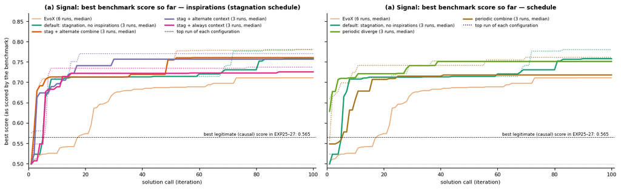

| Configuration | Runs | Best (median) | Best (top run) | Look-ahead ≥ 0.615 | Best causal (median) | Best causal (top) | Mode mix | SciPy introduced per mode |
| --- | --- | --- | --- | --- | --- | --- | --- | --- |
| default: stagnation, no inspirations | 3 | 0.758 | 0.780 | 3/3 (calls 2, 6, 22) | 0.523 | 0.539 | diverge 19%, free 81% | free 6/189, diverge 14/44 |
| stag + alternate combine | 3 | 0.760 | 0.780 | 3/3 (calls 2, 3, 26) | 0.502 | 0.523 | combine 9%, diverge 10%, free 81% | free 8/64, diverge 3/8, combine 1/6 |
| stag + alternate context | 3 | 0.757 | 0.770 | 3/3 (calls 3, 3, 6) | 0.499 | 0.499 | combine 9%, diverge 10%, free 81% | free 9/89, diverge 4/11, combine 4/9 |
| stag + always context | 3 | 0.725 | 0.737 | 3/3 (calls 4, 6, 7) | 0.499 | 0.534 | combine 19%, free 81% | free 18/91, combine 8/21 |
| periodic diverge | 3 | 0.751 | 0.752 | 3/3 (calls 1, 1, 7) | 0.499 | 0.529 | diverge 33%, free 67% | free 1/97, diverge 16/48 |
| periodic combine | 3 | 0.718 | 0.761 | 3/3 (calls 2, 8, 85) | 0.537 | 0.556 | combine 33%, free 67% | free 1/140, combine 5/69 |

```python
import os
PB = R / 'EXP28/results/partB_20261007T160822/analysis.json'
eB = json.loads(PB.read_text()) if PB.exists() else None
ARMS_B = {'vs_default': ('default: stagnation, no inspirations', '#1b9e77'), 'vs_stag_alt_combine': ('stag + alternate combine', '#d95f02'),
          'vs_stag_alt_context': ('stag + alternate context', '#7570b3'), 'vs_stag_always_context': ('stag + always context', '#e7298a'),
          'vs_periodic_diverge': ('periodic diverge', '#66a61e'), 'vs_combine': ('periodic combine', '#a6761d')}
if eB is None:
    print('Part B analysis not available yet:', PB)
else:
    S = eB['summary']
    def rate(arm, *modes):
        k = n = 0
        for m in modes:
            if m in S[arm]['scipy_yield']:
                a_, b_ = map(int, S[arm]['scipy_yield'][m].split('/')); k += a_; n += b_
        return f'{k}/{n} ({k / n:.0%})' if n else '–'
    display(Markdown(f'''**Summary (computed from the Part B analysis).**
- **Regression check:** the default re-run has a median best of {S['vs_default']['median_best_valid']:.3f} (Part A: 0.748),
  with look-ahead in {S['vs_default']['lookahead_runs']} runs, at calls {', '.join(map(str, S['vs_default']['lookahead_at']))}.
- **DIVERGE works once the leak is fixed:** it introduces a SciPy filter in {rate('vs_default', 'diverge')} of calls in the
  default, against {rate('vs_default', 'free')} for free calls. Periodic DIVERGE gives {rate('vs_periodic_diverge', 'diverge')}.
- **The explicit combine sentence limits it:** periodic combine gives {rate('vs_combine', 'combine')}. EvoX-style context
  inspirations do not: always-context gives {rate('vs_stag_always_context', 'combine')}, alternate-context {rate('vs_stag_alt_context', 'combine')}.
- **No legitimate gain:** median best causal scores are {min(S[a]['median_best_causal'] for a in ARMS_B):.3f}–{max(S[a]['median_best_causal'] for a in ARMS_B):.3f}.
  Look-ahead is found in every run, mostly within 10 calls.'''))
    fig, axs = plt.subplots(1, 2, figsize=(13, 3.9), constrained_layout=True, sharey=True)
    groups = (['vs_default', 'vs_stag_alt_combine', 'vs_stag_alt_context', 'vs_stag_always_context'], ['vs_default', 'vs_periodic_diverge', 'vs_combine'])
    titles = ('(a) Signal: best benchmark score so far — inspirations (stagnation schedule)', '(a) Signal: best benchmark score so far — schedule')
    for ax_, arms, title in zip(axs, groups, titles):
        m = np.array([best_so_far(curves[k]['points'], False) for k, r in curves.items() if GROUP(r['arm']) == 'EvoX'])
        ax_.plot(it, np.median(m, 0), '-', color=COL['EvoX'], lw=1.2, alpha=0.6, label=f'EvoX ({len(m)} runs, median)')
        for arm in arms:
            rs = [r for r in eB['runs'].values() if r['arm'] == arm]
            if not rs:
                continue
            m = np.array([best_so_far([tuple(p) for p in r['points']], False) for r in rs]); name, colour = ARMS_B[arm]
            ax_.plot(it, np.median(m, 0), '-', color=colour, lw=2, label=f'{name} ({len(rs)} runs, median)')
            ax_.plot(it, m[m[:, -1].argmax()], ':', color=colour, lw=1.1)
        ax_.plot([], [], 'k:', lw=1.1, label='top run of each configuration')
        ax_.axhline(MAX_CAUSAL, color='black', lw=0.6, ls='--'); ax_.axhline(INIT, color='grey', lw=0.6, ls=':')
        ax_.text(99, MAX_CAUSAL + 0.004, f'best legitimate (causal) score in EXP25–27: {MAX_CAUSAL:.3f}', ha='right', fontsize=6.5)
        ax_.set(title=title, xlabel='solution call (iteration)', xlim=(0, 101), ylim=(0.49, 0.87))
        ax_.legend(fontsize=6.5, loc='upper left', frameon=False, ncol=2)
    axs[0].set_ylabel('best score (as scored by the benchmark)')
    plt.show()
    rows = []
    for arm in ARMS_B:
        if arm not in eB['summary']:
            continue
        s = eB['summary'][arm]; rs = [r for r in eB['runs'].values() if r['arm'] == arm]
        mix = {}
        for r in rs:
            for k, v in (r.get('mode_mix') or {}).items():
                mix[k] = mix.get(k, 0) + v
        total = sum(mix.values()) or 1
        rows.append({'Configuration': ARMS_B[arm][0], 'Runs': s['runs'], 'Best (median)': s['median_best_valid'], 'Best (top run)': max(r['best_valid'] for r in rs),
                     'Look-ahead ≥ 0.615': s['lookahead_runs'] + (f" (calls {', '.join(map(str, s['lookahead_at']))})" if s['lookahead_at'] else ''),
                     'Best causal (median)': s['median_best_causal'], 'Best causal (top)': max(r['best_causal'] for r in rs),
                     'Mode mix': ', '.join(f'{k} {v / total:.0%}' for k, v in sorted(mix.items())),
                     'SciPy introduced per mode': ', '.join(f'{k} {v}' for k, v in s['scipy_yield'].items()) or '–'})
    display(pd.DataFrame(rows).style.hide(axis='index').format({c: '{:.3f}' for c in ['Best (median)', 'Best (top run)', 'Best causal (median)', 'Best causal (top)']})
            .background_gradient(subset=['Best (median)'], cmap='Oranges', vmin=0.5, vmax=0.78).set_table_styles(small))
```

## EXP28 Part C: the same VariationSearch configurations on PRISM, plus stock EvoX (7 arms × 3 seeds × 100 calls)

The trainer runs use EXP24's lower-level treatment: all-case valid score, per-case feedback, and a fallback projection, so refusing hard cases cannot pay. EvoX optimizes the stock metric and is free to exploit it. Each candidate is scored both ways: the *stock* metric (as reported by the benchmark) and the *all-case* score (every one of the 50 cases counts; optimum 26.256).

**Summary (computed from the Part C analysis).**

- **default: stagnation, no inspirations**: optimum (all-case 26.256) reached in 3/3 runs, at calls 3, 3, 4; median best stock 26.26, median best all-case 26.256.

- **stag + alternate combine**: optimum (all-case 26.256) reached in 2/3 runs, at calls 6, 7; median best stock 26.28, median best all-case 26.256.

- **stag + alternate context**: optimum (all-case 26.256) reached in 2/3 runs, at calls 4, 14; median best stock 26.36, median best all-case 26.256.

- **stag + always context**: optimum (all-case 26.256) reached in 3/3 runs, at calls 3, 5, 9; median best stock 26.26, median best all-case 26.256.

- **periodic diverge**: optimum (all-case 26.256) reached in 3/3 runs, at calls 2, 3, 7; median best stock 26.26, median best all-case 26.256.

- **periodic combine**: optimum (all-case 26.256) reached in 3/3 runs, at calls 6, 7, 7; median best stock 26.26, median best all-case 26.256.

- **stock EvoX**: optimum (all-case 26.256) reached in 1/3 runs, at calls 37; median best stock 25.88, median best all-case 24.149.

- Reference (EXP24, same lower level, 3 seeds): median calls to optimum fixed 12, llm_rewrite 12, Trace 22.

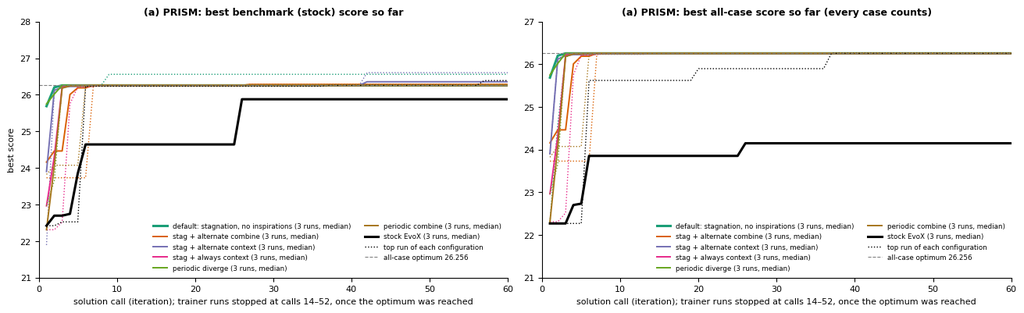

| Configuration | Runs | Best stock (median) | Best all-case (median) | Reached optimum | Calls to optimum | Mode mix |
| --- | --- | --- | --- | --- | --- | --- |
| default: stagnation, no inspirations | 3 | 26.256 | 26.256 | 3/3 | 3, 3, 4 | – |
| stag + alternate combine | 3 | 26.282 | 26.256 | 2/3 | 6, 7 | – |
| stag + alternate context | 3 | 26.355 | 26.256 | 2/3 | 4, 14 | – |
| stag + always context | 3 | 26.256 | 26.256 | 3/3 | 3, 5, 9 | – |
| periodic diverge | 3 | 26.256 | 26.256 | 3/3 | 2, 3, 7 | – |
| periodic combine | 3 | 26.256 | 26.256 | 3/3 | 6, 7, 7 | – |
| stock EvoX | 3 | 25.877 | 24.149 | 1/3 | 37 | – |

```python
PC = sorted((R / 'EXP28/results').glob('prism_*/analysis.json'))
eC = json.loads(PC[-1].read_text()) if PC else None
ARMS_C = {**ARMS_B, 'evox_stock': ('stock EvoX', 'black')}
def prism_curve(points, idx):
    by = {}
    for p in points:
        by[p[0]] = max(by.get(p[0], -1), p[idx])
    best, row = prism_rescore['initial']['metrics']['valid_score'], []
    for k in it:
        best = max(best, by.get(k, -1)); row.append(best)
    return np.array(row)
if eC is None:
    print('Part C analysis not available yet')
else:
    S = eC['summary']
    order = [a for a in ARMS_C if a in S]
    fast = [a for a in order if S[a]['median_calls_to_optimum'] is not None]
    display(Markdown('**Summary (computed from the Part C analysis).**\n' + '\n'.join(
        f"- **{ARMS_C[a][0]}**: optimum (all-case {OPT:.3f}) reached in {S[a]['reached_optimum']} runs"
        + (f", at calls {', '.join(map(str, S[a]['calls_to_optimum']))}" if S[a]['calls_to_optimum'] else '')
        + f"; median best stock {S[a]['median_best_stock']:.2f}, median best all-case {S[a]['median_best_allcase']:.3f}." for a in order)
        + f"\n- Reference (EXP24, same lower level, 3 seeds): median calls to optimum fixed 12, llm_rewrite 12, Trace 22."))
    fig, axs = plt.subplots(1, 2, figsize=(13, 3.9), constrained_layout=True)
    for ax_, idx, title, ylim in ((axs[0], 1, '(a) PRISM: best benchmark (stock) score so far', (21, 28)),
                                  (axs[1], 2, '(a) PRISM: best all-case score so far (every case counts)', (21, 27))):
        for arm in order:
            rs = [r for r in eC['runs'].values() if r['arm'] == arm]
            m = np.array([prism_curve(r['points'], idx) for r in rs]); name, colour = ARMS_C[arm]
            ax_.plot(it, np.median(m, 0), '-', color=colour, lw=2.2 if arm in ('evox_stock', 'vs_default') else 1.4, label=f'{name} ({len(rs)} runs, median)')
            ax_.plot(it, m[m[:, -1].argmax()], ':', color=colour, lw=1.0)
        ax_.plot([], [], 'k:', lw=1.0, label='top run of each configuration')
        ax_.axhline(OPT, color='grey', lw=0.8, ls='--', label=f'all-case optimum {OPT:.3f}')
        ax_.set(title=title, xlabel='solution call (iteration); trainer runs stopped at calls 14–52, once the optimum was reached', xlim=(0, 60), ylim=ylim)
        ax_.legend(fontsize=6.3, loc='lower right', frameon=False, ncol=2)
    axs[0].set_ylabel('best score')
    plt.show()
    rows = [{'Configuration': ARMS_C[a][0], 'Runs': S[a]['runs'], 'Best stock (median)': S[a]['median_best_stock'],
             'Best all-case (median)': S[a]['median_best_allcase'], 'Reached optimum': S[a]['reached_optimum'],
             'Calls to optimum': ', '.join(map(str, S[a]['calls_to_optimum'])) or '–',
             'Mode mix': ', '.join(f'{k} {v}' for k, v in sorted(sum((list(r['mode_mix'].items()) for r in eC['runs'].values() if r['arm'] == a), []),
                                                              key=lambda kv: kv[0])) or '–'} for a in order]
    for r in rows:
        if r['Mode mix'] != '–':
            agg = {}
            for k_v in r['Mode mix'].split(', '):
                k, v = k_v.rsplit(' ', 1); agg[k] = agg.get(k, 0) + int(v)
            total = sum(agg.values()); r['Mode mix'] = ', '.join(f'{k} {v / total:.0%}' for k, v in sorted(agg.items()))
    display(pd.DataFrame(rows).style.hide(axis='index').format({'Best stock (median)': '{:.3f}', 'Best all-case (median)': '{:.3f}'})
            .set_table_styles(small))
```